# ggplot2

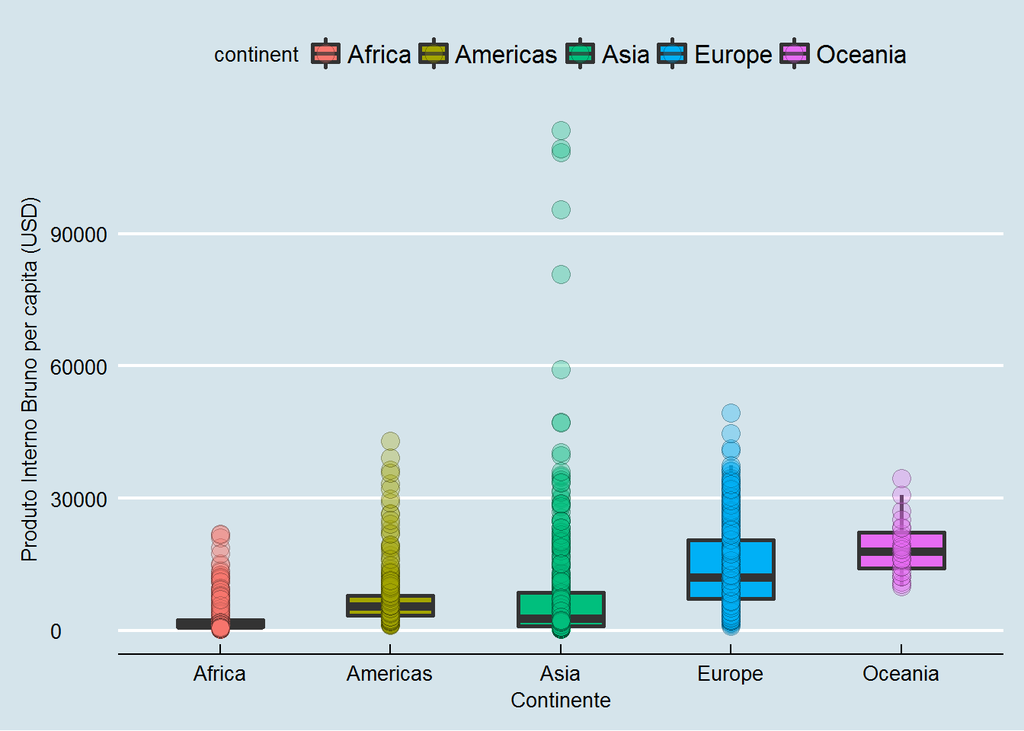

```r
# um dos temas disponíveis no pacote ggthemes
figura +
  ggthemes::theme_economist()
```

Entretanto, ao invés de usar estas opções pré-editadas de `theme`, sugiro que sempre tentemos editar manualmente estas opções, através da função `theme()`. Aqui, existem diversas opções a serem editadas, em grande parte de forma bem intuitiva. Além disso, cada uma dessas opções de edição pode ser resumida em quatro “tipos” principais de elementos:

- `element_text`: elementos textuais;
- `element_rect`: elementos que têm a forma de um retângulo;
- `element_line`: elementos que têm a forma de linha;
- `element_blank`: suprime uma opção.

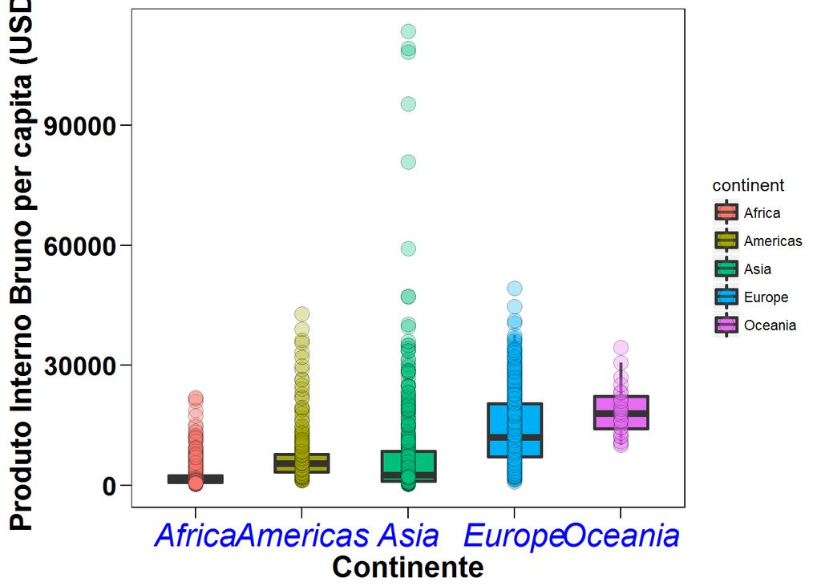

```r
figura +
  theme(axis.text = element_text(face = "bold", size = 16, colour = "black"),
        axis.title = element_text(face = "bold", size = 18, colour = "black"),
        axis.text.x = element_text(face = "italic", size = 20, colour = "blue"),
        panel.grid = element_blank(),
        panel.background = element_rect(fill = "white", color = "black"),
        axis.ticks = element_line(colour = "black"),
        axis.ticks.length = unit(x = 0.25, units = "cm"))
```

Além disso, o `theme` que nós personalizarmos pode ser armazenado como um objeto, e usado diretamente ao criarmos um gráfico do `ggplot`. Isto se torna muito útil uma vez que “acertamos” o tipo de características que queremos em um gráfico e/ou queremos produzir múltiplos gráficos com a aparência semelhante.

```r
# criando um objeto para armazenar as opções do tema
meu_tema <-   theme(axis.text = element_text(face = "bold", size = 16, colour = "black"),
                    axis.title = element_text(face = "bold", size = 18, colour = "black"),
                    axis.text.x = element_text(face = "italic", size = 20, colour = "blue"),
                    panel.grid = element_blank(),
                    panel.background = element_rect(fill = "white", color = "black"),
                    axis.ticks = element_line(colour = "black"),
                    axis.ticks.length = unit(x = 0.25, units = "cm"),
                    legend.position = "none")
```

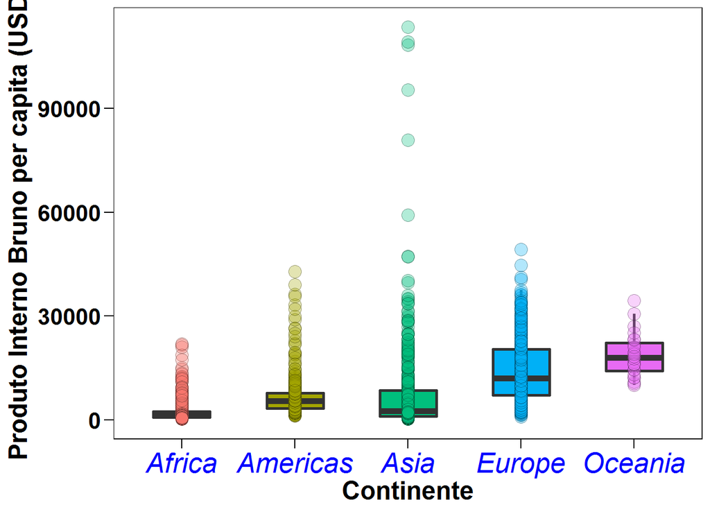

```r
# usando o objeto criado para o nosso tema
figura +
  meu_tema
```

##### Exercício 5

Crie um gráfico utilizando o conjunto de dados `mtcars`, demonstrando a relação entre a potência do carro `hp` e peso do carro `wt`, e:  
a. Modifique pelo menos 3 opções gráficas dos pontos;  
b. Modifique os títulos dos dois eixos;  
c. Modifique os `breaks` de pelo menos um dos eixos;  
d. Crie um tema para modificar essa cara de gráfico do `ggplot`.

Uma observação importante é que podemos também modificar o sistema de coordenadas de um gráfico do R. Um exemplo de modificação destas coordenadas é no caso de querermos inverter os eixos x e y no gráfico final (`coord_flip`). Outras aplicações são na criação de gráficos de pizza (`coord_polar`) e na criação de mapas (`coord_quickmap` e `coord_map`).

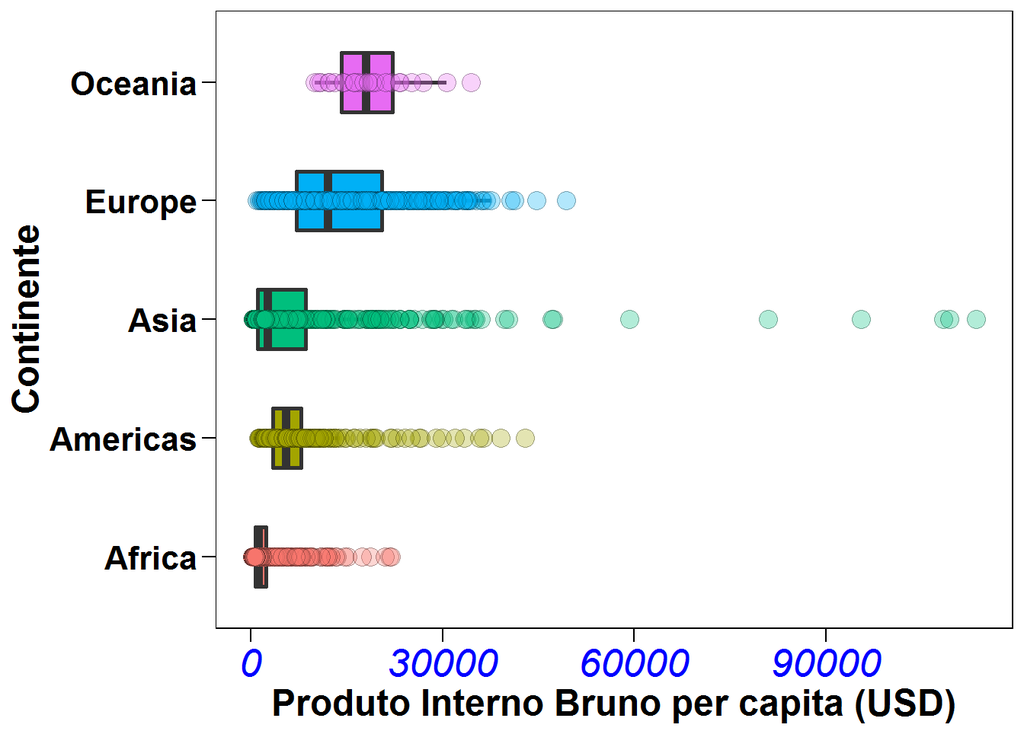

```r
figura +
  meu_tema +
  coord_flip()
```

Dentro das opções `coord_?` também podemos determinar quais são os limites dos eixos x e y, bem como determinar se queremos que o `ggplot` adicione um espaço extra para além destes limites que traçamos.

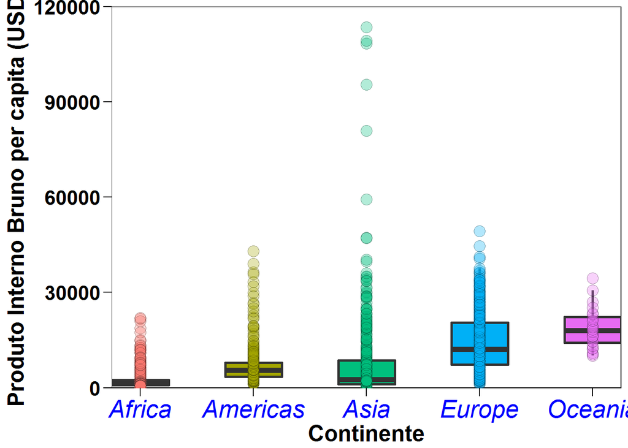

```r
figura +
  meu_tema+
  coord_cartesian(ylim = c(0, 120000), expand = FALSE)
```

Muitos destes últimos parametros gráficos também podem ser manipulados de forma direta como funções ou argumentos em outras funções:

- função `ylim` para traçar os limites do eixo y;
- função `ylab` para adicionar uma legenda ao eixo y;
- função `xlim` para traçar os limites do eixo x;
- função `xlab` para adicionar uma legenda ao eixo x;
- argumento `limits` em `scale_x_?` ou `scale_y_?` para traçar os limites do eixo x e y, respectivamente;
- argumento `expand` em `scale_x_?` ou `scale_y_?` para determinar se deve ser adicionado um fator de expansão aos limites do plot.

Por fim, às vezes precisamos adicionar algum tipo de informação a um gráfico já criado: um texto, algum desenho ou mesmo um outro gráfico (*inset*). Fazer estes *insets* é bem trabalhoso, mas possível no R - portanto, só quero que você saiba que existe essa opção, mas não vamos tratar disto aqui. Por outro lado, é bem simples adicionar algum texto ou desenho extra em um gráfico criado, através da função `annotate`.

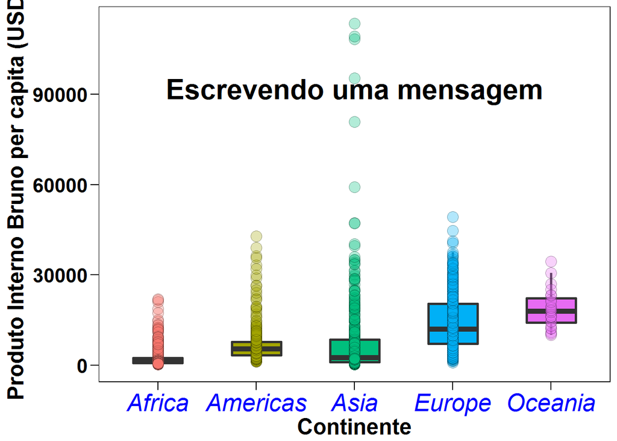

```r
figura +
  meu_tema +
  annotate(geom = "text", x = 3, y = 92000, label = "Escrevendo uma mensagem", fontface = "bold", size = 8)
```

O `ggplot2` pode interagir com os outros pacotes que compõem o `tidyverse`. Isto é muito útil, pois reduz ainda mais a distância entre a pergunta e a resposta. Por exemplo: como variou o produto interno bruto per capita no Brasil ao longo dos anos?

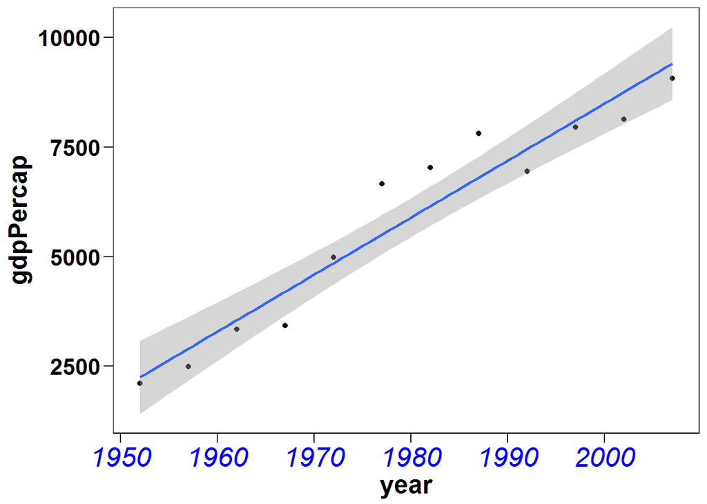

```r
# dados do GDP para o Brasil
dados_brasil <- gapminder %>%
  filter(country == "Brazil") %>%
  select(year, gdpPercap)

# criando figura para mostrar relação
ggplot(data = dados_brasil, mapping = aes(x = year, y = gdpPercap)) +
  geom_point() +
  geom_smooth(method = "lm") +
  meu_tema
```

Podemos aproveitar essa integração para criar variáveis antes de criarmos a figura:

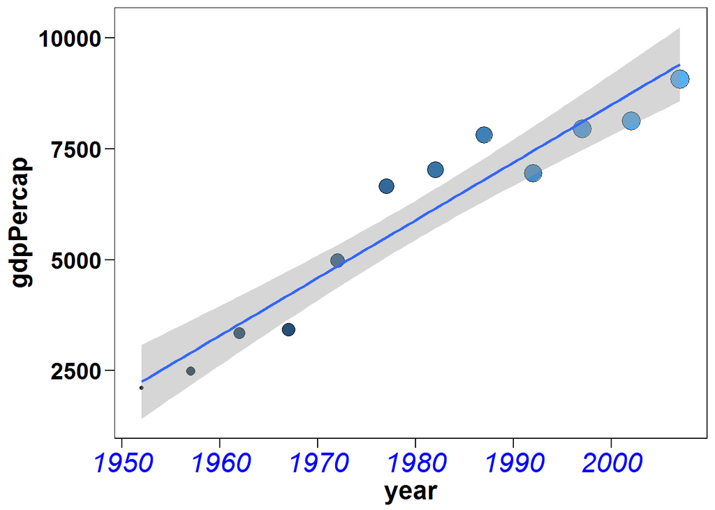

```r
# dados do GDP para o Brasil
dados_brasil <- gapminder %>%
  filter(country == "Brazil") %>%
  mutate(log_populacao = log10(pop))

# criando figura para mostrar relação
ggplot(data = dados_brasil, mapping = aes(x = year, y = gdpPercap, size = log_populacao, fill = lifeExp)) +
  geom_point(shape = 21) +
  geom_smooth(method = "lm") +
  meu_tema
```

Entretanto, fazer parte do `tidyverse` traz também a vantagem de integrarmos toda a manipulação de dados com a criação da figura através do operador `pipe` - sem a necessidade de dizer qual o conjunto de dados estamos trabalhando:

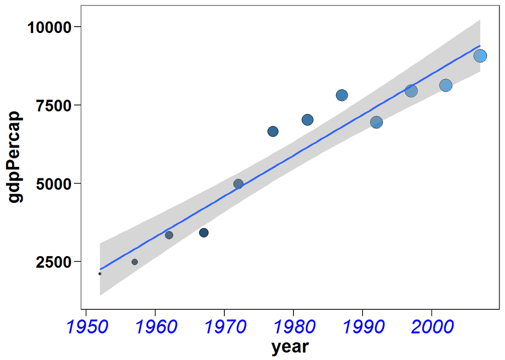

```r
gapminder %>%
  filter(country == "Brazil") %>%
  mutate(log_populacao = log10(pop)) %>%
  ggplot(mapping = aes(x = year, y = gdpPercap, size = log_populacao, fill = lifeExp)) +
  geom_point(shape = 21) +
  geom_smooth(method = "lm") +
  meu_tema
```

Dessa forma, fazer gráficos usando o `ggplot2` e as demais ferramentas do `tidyverse` não é só mais intuitivo, mas muito mais prático do que se usarmos as funções da `base` do R.

##### Exercício 6

Gráficos de barra e erro padrão da média (ou gráficos de ponto e intervalos de confiança de 95%) são duas coisas muito comuns que nós, ecólogos gostamos de fazer. Vamos praticar a manipulação de dados com a criação de figuras de forma integrada com o operador `pipe` usando o conjunto de dados das enquetes, que limpamos anteriormente (todas as perguntas devem ser respondidas com gráficos). Note que em cada uma das tarefas, é necessário: ajustar o `theme`, ajustar os eixos x e y (limits, expand, títulos, breaks) e customizar as cores/shape das barras e/ou pontos.

1. Carregue o conjunto de dados limpos das enquetes, que limpamos na aula anterior - ele está no diretório `11_manipulacao_de_dados`, no sub-diretorio `dados` e recebeu o nome de `dados_limpos.xls`. Caso você queira, renomeie os nomes das colunas para que fique mais fácil fazer as operações a seguir.
2. Quantas pessoas já fizeram esta disciplina? (**dica:** `geom_bar`)
3. Quantas pessoas fizeram esta disciplina em cada um dos anos que ela foi ofertada? (**dica:** `geom_bar`)
4. Quantas pessoas que fizeram esta disciplina já haviam usado o R? (**dica:** `geom_bar`)
5. Este padrão parece diferir entre esta turma e a anterior?
6. Quantos cursos em média (e o erro padrão da média) cada aluno já havia feito antes de prestar esta disciplina (apresente o gráfico como um ponto e o erro padrão da média como linhas; **dica:** `geom_point` e `geom_errorbar`)?
7. Para os alunos que não são ouvintes da disciplina, qual o prazo médio para a defesa? Separe os alunos entre estudantes de mestrado e de doutorado, use um gráfico de barras e apresente o intervalo de confiança de 95% (**dica:** `geom_bar` e `geom_errorbar`).

Na aula do `plot` na `base` do função R, vimos que para termos uma figura de alta qualidade não devemos usar a opção `Export` na aba `Plot`. Lá, vimos que podemos usar as funções `pdf`, `tiff` e `jpeg` (por exemplo) para gerar e salvar o gráfico de alta qualidade em nosso computador.

O `ggplot2` possui uma função especial para isso: a função `ggsave`. Esta função elimina a necessidade de usar uma função em especial para cada formato de arquivo que você quer usar, pois você determina diretamente nela o tipo de extensão do arquivo gerado e todas as demais informações.

```r
ggsave(filename = "figuras/exemplo.pdf", plot = figura, width = 15, height = 10, dpi = 200)
```

- **Dica do R:** para gráficos com mais de um painel, você pode usar as funções nos pacotes `grid` e `grid.Extra` para juntar os múltiplos painéis, e depois usar as funções do pacote `base` ou o `ggsave` para salvá-las.

## Mais sobre o `ggplot2`

- No livro *ggplot2*: http://ggplot2.org/book/;
- No site: http://ggplot2.tidyverse.org/reference/;
- No livro *“R for Data Science”*: http://r4ds.had.co.nz/data-visualisation.html;
- O Google.